# Introduction to Data

Modified Data Camp Material

Aug 29, 2018

# 1 Chapter One

What is **Data**?

> Data is any collection of numbers, characters, images, or other items that provide information about something.

For **Data** to be useful, you should be able to answer **Who** and **What** at a minimum. — Better to be able to answer who, what, when, where, why, and how.

### 1.0.1 High School and Beyond

- Use `head()` and `tail()`
- Use `str()`
- If on PC to insert R code chunk use `CTRL ALT I`
- If on a MAC to insert R code chunk use `ALT COMMAND I`

```r
library(openintro)
head(hsb2, n = 3)
```

```
   id gender  race    ses schtyp       prog read write math science socst
1  70   male white    low public    general   57    52   41      47    57
2 121 female white middle public vocational   68    59   53      63    61
3  86   male white   high public    general   44    33   54      58    31
```

```r
str(hsb2)
```

```
'data.frame':   200 obs. of  11 variables:
 $ id     : int  70 121 86 141 172 113 50 11 84 48 ...
 $ gender : chr  "male" "female" "male" "male" ...
 $ race   : chr  "white" "white" "white" "white" ...
 $ ses    : Factor w/ 3 levels "low","middle",..: 1 2 3 3 2 2 2 2 2 2 ...
 $ schtyp : Factor w/ 2 levels "public","private": 1 1 1 1 1 1 1 1 1 1 ...
 $ prog   : Factor w/ 3 levels "general","academic",..: 1 3 1 3 2 2 1 2 1 2 ...
 $ read   : int  57 68 44 63 47 44 50 34 63 57 ...
 $ write  : int  52 59 33 44 52 52 59 46 57 55 ...
 $ math   : int  41 53 54 47 57 51 42 45 54 52 ...
 $ science: int  47 63 58 53 53 63 53 39 58 50 ...
 $ socst  : int  57 61 31 56 61 61 61 36 51 51 ...
```

- Using `datatable()` from `DT`

|  | id | gender | race | ses | schtyp | prog | read | write | math | science | socst |
| --- | --- | --- | --- | --- | --- | --- | --- | --- | --- | --- | --- |
| 1 | 70 | male | white | low | public | general | 57 | 52 | 41 | 47 | 57 |
| 2 | 121 | female | white | middle | public | vocational | 68 | 59 | 53 | 63 | 61 |
| 3 | 86 | male | white | high | public | general | 44 | 33 | 54 | 58 | 31 |
| 4 | 141 | male | white | high | public | vocational | 63 | 44 | 47 | 53 | 56 |
| 5 | 172 | male | white | middle | public | academic | 47 | 52 | 57 | 53 | 61 |
| 6 | 113 | male | white | middle | public | academic | 44 | 52 | 51 | 63 | 61 |
| 7 | 50 | male | african american | middle | public | general | 50 | 59 | 42 | 53 | 61 |
| 8 | 11 | male | hispanic | middle | public | academic | 34 | 46 | 45 | 39 | 36 |
| 9 | 84 | male | white | middle | public | general | 63 | 57 | 54 | 58 | 51 |
| 10 | 48 | male | african american | middle | public | academic | 57 | 55 | 52 | 50 | 51 |

[output cut: 190 more lines]

### 1.0.2 Tables

```r
table(hsb2$schtyp)
```

```
 public private
    168      32
```

```r
# or
xtabs(~schtyp, data = hsb2)
```

```
schtyp
 public private
    168      32
```

### 1.0.3 Use `filter()` to subset (part of `dplyr`)

```r
library(dplyr)
hsb2_public <- hsb2 %>%
  filter(schtyp == "public")
table(hsb2_public$schtyp)
```

```
 public private
    168       0
```

```r
# or
xtabs(~schtyp, data = hsb2_public)
```

```
schtyp
 public private
    168       0
```

### 1.0.4 Drop (unused) levels

```r
hsb2_public$schtyp <- droplevels(hsb2_public$schtyp)
table(hsb2_public$schtyp)
```

```
public
   168
```

```r
# Or
xtabs(~schtyp, data = hsb2_public)
```

```
schtyp
public
   168
```

### 1.0.5 Discretizing a variable

#### 1.0.5.1 Average reading score

```r
(avg_read <- mean(hsb2$read))
```

```
[1] 52.23
```

```r
hsb2_mine <- hsb2 %>%
  mutate(read_cat = ifelse(read < avg_read,
                           "below average",
                           "at or above average")) %>%
  select(id, read, read_cat)
DT::datatable(hsb2_mine)
```

|  | id | read | read_cat |
| --- | --- | --- | --- |
| 1 | 70 | 57 | at or above average |
| 2 | 121 | 68 | at or above average |
| 3 | 86 | 44 | below average |
| 4 | 141 | 63 | at or above average |
| 5 | 172 | 47 | below average |
| 6 | 113 | 44 | below average |
| 7 | 50 | 50 | below average |
| 8 | 11 | 34 | below average |
| 9 | 84 | 63 | at or above average |
| 10 | 48 | 57 | at or above average |

[output cut: 190 more lines]

### 1.0.6 Combining levels of a different factor

Another common way of creating a new variable based on an existing one is by combining levels of a categorical variable. For example, the `email50` dataset has a categorical variable called `number` with levels “none”, “small”, and “big”, but suppose we’re only interested in whether an email contains a number. In this exercise, we will create a variable containing this information and also visualize it.

- Create a new column in `email50` called `number_yn` that is “no” if there is no number in the email and “yes” otherwise. Use `case_when()` for this. Assign this to `email50_fortified`.
- Run the code provided to visualize the distribution of the `number_yn` variable.

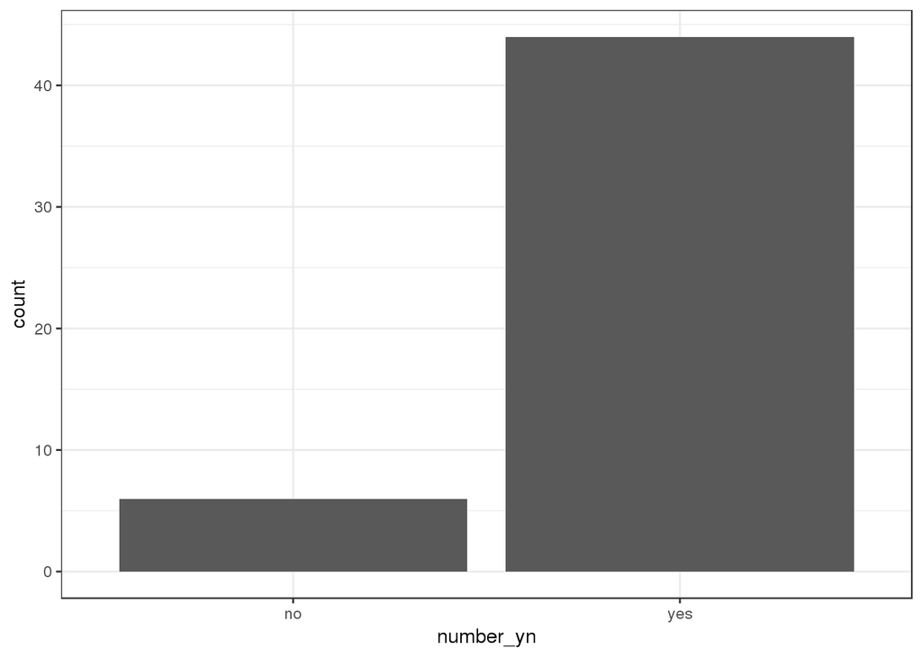

```r
# Create number_yn variable in email50
email50_fortified <- email50 %>%
  mutate(number_yn = case_when(
    number == "none" ~ "no",
    number != "none" ~ "yes"
    )
  )
library(ggplot2)
# Visualize number_yn
ggplot(email50_fortified, aes(x = number_yn)) +
  geom_bar() +
  theme_bw()
```

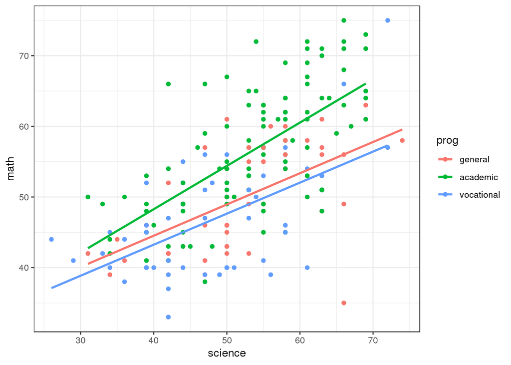

```r
library(ggplot2)
ggplot(data = hsb2, aes(x = science, y = math, color = prog)) +
  geom_point() +
  geom_smooth(method = "lm", se = FALSE) +
  theme_bw()
```

# 2 Chapter 2

## 2.1 Types of studies

- Observational study:
- collect data in a way that does not directly interfere with how the data arise
- Only association can be inferred
- Experiment:
- Randomly assign subject to various treatments
- Causation can be inferred

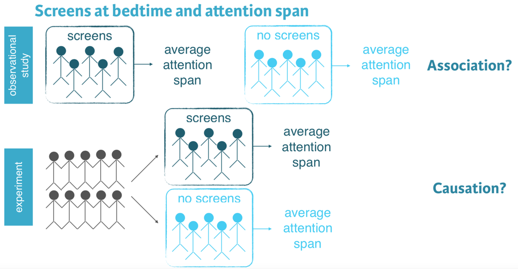

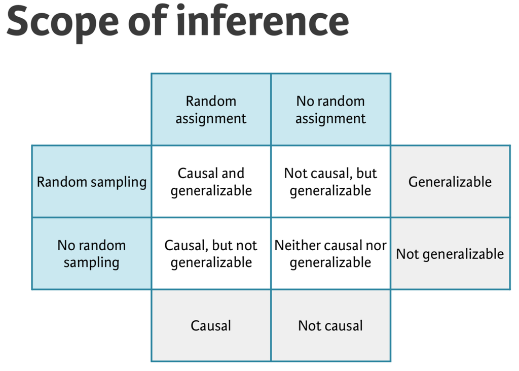

## 2.2 Simpson’s Paradox

### 2.2.1 Number of males and females admitted

The goal of this exercise is to determine the numbers of male and female applicants who got admitted and rejected. Specifically, we want to find out how many males are admitted and how many are rejected. And similarly we want to find how many females are admitted and how many are rejected.

To do so we will use the `count()` function from the `dplyr` package.

In one step, `count()` groups the data and then tallies the number of observations in each level of the grouping variable. These counts are available under a new variable called `n`.

Pass the gender and admission status columns to `count()` on the `ucb_admit` dataset (created below) to count how many of each gender are admitted and how many are rejected.

```r
# Creating ucb_admit
UCB <- as.data.frame(UCBAdmissions)
ucb_admit <- vcdExtra::expand.dft(UCB)
#
ucb_counts <- ucb_admit %>%
  count(Gender, Admit)
# View result
ucb_counts
```

```
# A tibble: 4 x 3
  Gender Admit        n
  <fct>  <fct>    <int>
1 Female Admitted   557
2 Female Rejected  1278
3 Male   Admitted  1198
4 Male   Rejected  1493
```

```r
# Spread
library(tidyr)
ucb_counts %>%
  spread(Admit, n)
```

```
# A tibble: 2 x 3
  Gender Admitted Rejected
  <fct>     <int>    <int>
1 Female      557     1278
2 Male       1198     1493
```

### 2.2.2 Proportion of males admitted overall

Next we will calculate the percentage of males and percentage of females admitted, by creating a new variable, called `prop` (short for proportion) based off of the counts calculated in the previous exercise and using the `mutate()` from the `dplyr` package.

Proportions for each row of the data frame we created in the previous exercise (`ucb_counts`) can be calculated as `n / sum(n)`. Note that since the data are grouped by gender, `sum(n)` will be calculated for males and females separately.

- Group the data by gender (`group_by()`)
- Create the new variable described above, `prop`, the proportion of males and females admitted.
- Filter the data for those who are admitted so that the resulting data frame only contains proportions of males and females who are admitted.
- Which gender has a higher admission rate, male or female?

```r
ucb_counts %>%
  # Group by gender
  group_by(Gender) %>%
  # Create new variable
  mutate(prop = n / sum(n)) %>%
  # Filter for admitted
  filter(Admit == "Admitted")
```

```
# A tibble: 2 x 4
# Groups:   Gender [2]
  Gender Admit        n  prop
  <fct>  <fct>    <int> <dbl>
1 Female Admitted   557 0.304
2 Male   Admitted  1198 0.445
```

```r
ucb_admit %>%
  # Table of counts of admission status and gender
  count(Admit, Gender) %>%
  # Spread output across columns based on admission status
  spread(Admit, n) %>%
  # Create new variable
  mutate(Perc_Admit = Admitted / (Admitted + Rejected))
```

```
# A tibble: 2 x 4
  Gender Admitted Rejected Perc_Admit
  <fct>     <int>    <int>      <dbl>
1 Female      557     1278      0.304
2 Male       1198     1493      0.445
```

**Note:** Males have the higher admission rate! Is this sex discrimination?

## 2.3 Proportion of males admitted for each department

Finally we will make a table similar to the one we constructed earlier, except we will first group the data by department. The goal is to compare the proportions of male admitted students across departments.

Proportions for each row of the data frame we create can be calculated as `n / sum(n)`. Note that since the data are grouped by department and gender, `sum(n)` will be calculated for males and females separately for each department.

Assign `ucb_admission_counts` as the `count()` of `ucb_admit` by department, gender, and admission status.

```r
ucb_admission_counts <- ucb_admit %>%
  count(Dept, Gender, Admit)
# See the result
ucb_admission_counts
```

```
# A tibble: 24 x 4
   Dept  Gender Admit        n
   <fct> <fct>  <fct>    <int>
 1 A     Female Admitted    89
 2 A     Female Rejected    19
 3 A     Male   Admitted   512
 4 A     Male   Rejected   313
 5 B     Female Admitted    17
 6 B     Female Rejected     8
 7 B     Male   Admitted   353
 8 B     Male   Rejected   207
 9 C     Female Admitted   202
10 C     Female Rejected   391
# ... with 14 more rows
```

- Group `ucb_admission_counts` by department then gender.
- Add a new column, `prop`, which is the ratio of those admitted or rejected by department and gender.
- Filter the rows for males and for those who are admitted.

```r
ucb_admission_counts  %>%
  # Group by department, then gender
  group_by(Dept, Gender) %>%
  # Create new variable
  mutate(prop = n/sum(n)) %>%
  # Filter for male and admitted
  filter(Gender == "Male", Admit == "Admitted")
```

```
# A tibble: 6 x 5
# Groups:   Dept, Gender [6]
  Dept  Gender Admit        n   prop
  <fct> <fct>  <fct>    <int>  <dbl>
1 A     Male   Admitted   512 0.621
2 B     Male   Admitted   353 0.630
3 C     Male   Admitted   120 0.369
4 D     Male   Admitted   138 0.331
5 E     Male   Admitted    53 0.277
6 F     Male   Admitted    22 0.0590
```

**Note:** The proportion of males admitted varies wildly between departments!

```r
ND2 <- ucb_admission_counts  %>%
  # Group by department, then gender
  group_by(Dept, Gender) %>%
  # Create new variable
  mutate(prop = n/sum(n)) %>%
  filter(Admit == "Admitted")
ND2
```

```
# A tibble: 12 x 5
# Groups:   Dept, Gender [12]
   Dept  Gender Admit        n   prop
   <fct> <fct>  <fct>    <int>  <dbl>
 1 A     Female Admitted    89 0.824
 2 A     Male   Admitted   512 0.621
 3 B     Female Admitted    17 0.68
 4 B     Male   Admitted   353 0.630
 5 C     Female Admitted   202 0.341
 6 C     Male   Admitted   120 0.369
 7 D     Female Admitted   131 0.349
 8 D     Male   Admitted   138 0.331
 9 E     Female Admitted    94 0.239
10 E     Male   Admitted    53 0.277
11 F     Female Admitted    24 0.0704
12 F     Male   Admitted    22 0.0590
```

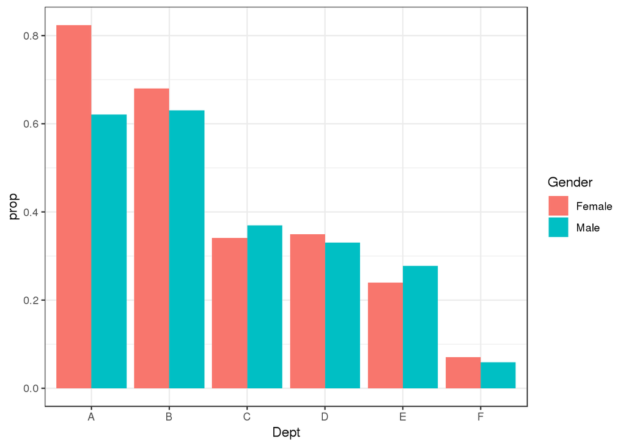

```r
library(ggplot2)
ggplot(data = ND2, aes(x = Dept, y = prop, fill = Gender)) +
  geom_bar(stat = "identity", position = "dodge") +
  theme_bw()
```

```r
ND <- UCB %>%
  group_by(Dept, Gender) %>%
  mutate(prop = Freq/sum(Freq)) %>%
  filter(Admit == "Admitted")
ND
```

```
# A tibble: 12 x 5
# Groups:   Dept, Gender [12]
   Admit    Gender Dept   Freq   prop
   <fct>    <fct>  <fct> <dbl>  <dbl>
 1 Admitted Male   A       512 0.621
 2 Admitted Female A        89 0.824
 3 Admitted Male   B       353 0.630
 4 Admitted Female B        17 0.68
 5 Admitted Male   C       120 0.369
 6 Admitted Female C       202 0.341
 7 Admitted Male   D       138 0.331
 8 Admitted Female D       131 0.349
 9 Admitted Male   E        53 0.277
10 Admitted Female E        94 0.239
11 Admitted Male   F        22 0.0590
12 Admitted Female F        24 0.0704
```

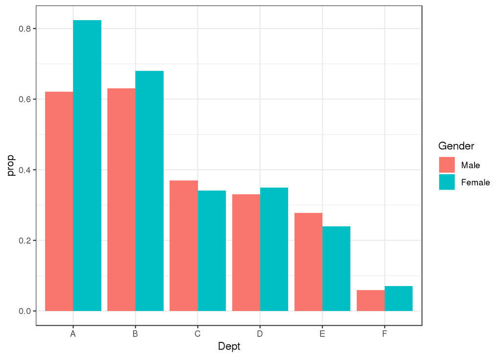

```r
ggplot(data = ND, aes(x = Dept, y = prop, fill = Gender)) +
  geom_bar(stat = "identity", position = "dodge") +
  theme_bw()
```

# 3 Why sample?

- Why not take a census?

## 3.1 Using `gapminder`

```r
library(gapminder)
gapminder
```

```
# A tibble: 1,704 x 6
   country     continent  year lifeExp      pop gdpPercap
   <fct>       <fct>     <int>   <dbl>    <int>     <dbl>
 1 Afghanistan Asia       1952    28.8  8425333      779.
 2 Afghanistan Asia       1957    30.3  9240934      821.
 3 Afghanistan Asia       1962    32.0 10267083      853.
 4 Afghanistan Asia       1967    34.0 11537966      836.
 5 Afghanistan Asia       1972    36.1 13079460      740.
 6 Afghanistan Asia       1977    38.4 14880372      786.
 7 Afghanistan Asia       1982    39.9 12881816      978.
 8 Afghanistan Asia       1987    40.8 13867957      852.
 9 Afghanistan Asia       1992    41.7 16317921      649.
10 Afghanistan Asia       1997    41.8 22227415      635.
# ... with 1,694 more rows
```

## 3.2 Sampling

```r
set.seed(123)
library(openintro)
library(dplyr)
data(county)
county_noDC <- county %>%
  filter(state != "District of Columbia") %>%
  droplevels()
county_srs <- county_noDC %>%
  sample_n(size = 150)
glimpse(county_srs)
```

```
Observations: 150
Variables: 10
$ name          <fct> Comanche County, Lawrence County, Menominee Coun...
$ state         <fct> Kansas, Tennessee, Michigan, Texas, Virginia, Ar...
$ pop2000       <dbl> 1967, 39926, 25326, 36752, 11998, 34233, 819, 29...
$ pop2010       <dbl> 1891, 41869, 24029, 41964, 14068, 36647, 690, 36...
$ fed_spend     <dbl> 9.509783, 9.451766, 7.288235, 8.384973, 23.14728...
$ poverty       <dbl> 8.9, 17.4, 12.2, 14.0, 16.5, 19.3, 16.1, 7.0, 12...
$ homeownership <dbl> 82.9, 77.9, 81.2, 81.4, 49.5, 72.8, 66.3, 74.4, ...
$ multiunit     <dbl> 6.1, 7.4, 9.2, 4.5, 36.3, 7.3, 7.2, 29.8, 14.4, ...
$ income        <dbl> 22974, 18086, 21624, 21682, 22851, 19912, 22042,...
$ med_income    <dbl> 34808, 34985, 41332, 41277, 50794, 34625, 34063,...
```

```r
county_srs %>%
  group_by(state) %>%
  count()
```

```
# A tibble: 42 x 2
# Groups:   state [42]
   state           n
   <fct>       <int>
 1 Alabama         2
 2 Alaska          1
 3 Arkansas        4
 4 California      1
 5 Colorado        3
 6 Connecticut     1
 7 Florida         3
 8 Georgia        11
 9 Idaho           2
10 Illinois        5
# ... with 32 more rows
```

## 3.3 Stratified sampling

```r
set.seed(123)
county_str <- county_noDC %>%
  group_by(state) %>%
  sample_n(size = 3)
glimpse(county_str)
```

```
Observations: 150
Variables: 10
$ name          <fct> Covington County, Perry County, Escambia County,...
$ state         <fct> Alabama, Alabama, Alabama, Alaska, Alaska, Alask...
$ pop2000       <dbl> 37631, 11861, 38440, 7028, NA, 5465, 3072149, 38...
$ pop2010       <dbl> 37765, 10591, 38319, 7459, 2369, 5561, 3817117, ...
$ fed_spend     <dbl> 9.461856, 12.354735, 7.805162, 14.112616, 0.0000...
$ poverty       <dbl> 19.0, 28.8, 24.4, 31.4, 8.3, 12.6, 13.9, 25.2, 2...
$ homeownership <dbl> 74.0, 67.8, 73.5, 64.8, 78.7, 36.3, 66.3, 71.0, ...
$ multiunit     <dbl> 6.1, 11.4, 7.8, 4.1, 11.9, 30.9, 25.1, 17.6, 12....
$ income        <dbl> 19822, 13433, 16259, 11269, 28731, 29920, 27816,...
$ med_income    <dbl> 33852, 25950, 31927, 37955, 50389, 72917, 55054,...
```

### 3.3.1 Simple random sample in R

Suppose we want to collect some data from a sample of eight states. A list of all states and the region they belong to (Northeast, Midwest, South, West) are given in the `us_regions` data frame.

```r
load("./DATA/us_regions.RData")
head(us_regions)
```

```
          state    region
1   Connecticut Northeast
2         Maine Northeast
3 Massachusetts Northeast
4 New Hampshire Northeast
5  Rhode Island Northeast
6       Vermont Northeast
```

- Use simple random sampling to select eight states from `us_regions`. Save this sample in a data frame called `states_srs`.
- Count the number of states from each region in your sample.

```r
set.seed(2)
states_srs <- us_regions %>%
  sample_n(size = 8)
#
states_srs %>%
  count(region)
```

```
# A tibble: 4 x 2
  region        n
  <fct>     <int>
1 Midwest       1
2 Northeast     2
3 South         3
4 West          2
```

Notice that this strategy may select an unequal number of states from each region. In the next exercise, you’ll implement stratified sampling to be sure to select an equal number of states from each region.

## 3.4 Stratified sample in R

In the previous exercise, we took a simple random sample of eight states. However, we did not have any control over how many states from each region got sampled. The goal of stratified sampling in this context is to have control over the number of states sampled from each region. Our goal for this exercise is to sample an equal number of states from each region.

- Use stratified sampling to select a total of eight states, where each stratum is a region. Save this sample in a data frame called `states_str`.
- Count the number of states from each region in your sample to confirm that each region is represented equally in your sample.

```r
states_str <- us_regions %>%
  group_by(region) %>%
  sample_n(size = 2)
states_str
```

```
# A tibble: 8 x 2
# Groups:   region [4]
  state        region
  <fct>        <fct>
1 Iowa         Midwest
2 Kansas       Midwest
3 Rhode Island Northeast
4 Maine        Northeast
5 Tennessee    South
6 Georgia      South
7 New Mexico   West
8 Hawaii       West
```

```r
states_str %>%
  count(region)
```

```
# A tibble: 4 x 2
# Groups:   region [4]
  region        n
  <fct>     <int>
1 Midwest       2
2 Northeast     2
3 South         2
4 West          2
```

In this stratified sample, each stratum (i.e. Region) is represented equally.

## 3.5 Principles of experimental design

- **Control:** compare treatment of interest to a control group
- **Randomize:** randomly assign subjects to treatments
- **Replicate:** collect a sufficiently large sample within a study, or replicate the entire study
- **Block:** account for the potential effect of confounding variables

**Explanatory** variables are conditions you can impose on the experimental units, while **Blocking** variables are characteristics that the experimental units come with that you would like to control.

In random sampling, we use **stratifying** to control for a variable. In random assignment, we use **blocking** to achieve the same goal.

# 4 Chapter 4

## 4.1 Inspect the data

The purpose of this chapter is to give you an opportunity to apply and practice what you’ve learned on a real world dataset. For this reason, we’ll provide a little less guidance than usual.

The data from the study described in the video are available in your workspace as `evals`. Let’s take a look!

```r
str(evals)
```

```
Classes 'tbl_df', 'tbl' and 'data.frame':   463 obs. of  21 variables:
 $ score        : num  4.7 4.1 3.9 4.8 4.6 4.3 2.8 4.1 3.4 4.5 ...
 $ rank         : Factor w/ 3 levels "teaching","tenure track",..: 2 2 2 2 3 3 3 3 3 3 ...
 $ ethnicity    : Factor w/ 2 levels "minority","not minority": 1 1 1 1 2 2 2 2 2 2 ...
 $ gender       : Factor w/ 2 levels "female","male": 1 1 1 1 2 2 2 2 2 1 ...
 $ language     : Factor w/ 2 levels "english","non-english": 1 1 1 1 1 1 1 1 1 1 ...
 $ age          : int  36 36 36 36 59 59 59 51 51 40 ...
 $ cls_perc_eval: num  55.8 68.8 60.8 62.6 85 ...
 $ cls_did_eval : int  24 86 76 77 17 35 39 55 111 40 ...
 $ cls_students : int  43 125 125 123 20 40 44 55 195 46 ...
 $ cls_level    : Factor w/ 2 levels "lower","upper": 2 2 2 2 2 2 2 2 2 2 ...
 $ cls_profs    : Factor w/ 2 levels "multiple","single": 2 2 2 2 1 1 1 2 2 2 ...
 $ cls_credits  : Factor w/ 2 levels "multi credit",..: 1 1 1 1 1 1 1 1 1 1 ...
 $ bty_f1lower  : int  5 5 5 5 4 4 4 5 5 2 ...
 $ bty_f1upper  : int  7 7 7 7 4 4 4 2 2 5 ...
 $ bty_f2upper  : int  6 6 6 6 2 2 2 5 5 4 ...
 $ bty_m1lower  : int  2 2 2 2 2 2 2 2 2 3 ...
 $ bty_m1upper  : int  4 4 4 4 3 3 3 3 3 3 ...
 $ bty_m2upper  : int  6 6 6 6 3 3 3 3 3 2 ...
 $ bty_avg      : num  5 5 5 5 3 ...
 $ pic_outfit   : Factor w/ 2 levels "formal","not formal": 2 2 2 2 2 2 2 2 2 2 ...
 $ pic_color    : Factor w/ 2 levels "black&white",..: 2 2 2 2 2 2 2 2 2 2 ...
```

```r
glimpse(evals)
```

```
Observations: 463
Variables: 21
$ score         <dbl> 4.7, 4.1, 3.9, 4.8, 4.6, 4.3, 2.8, 4.1, 3.4, 4.5...
$ rank          <fct> tenure track, tenure track, tenure track, tenure...
$ ethnicity     <fct> minority, minority, minority, minority, not mino...
$ gender        <fct> female, female, female, female, male, male, male...
$ language      <fct> english, english, english, english, english, eng...
$ age           <int> 36, 36, 36, 36, 59, 59, 59, 51, 51, 40, 40, 40, ...
$ cls_perc_eval <dbl> 55.81395, 68.80000, 60.80000, 62.60163, 85.00000...
$ cls_did_eval  <int> 24, 86, 76, 77, 17, 35, 39, 55, 111, 40, 24, 24,...
$ cls_students  <int> 43, 125, 125, 123, 20, 40, 44, 55, 195, 46, 27, ...
$ cls_level     <fct> upper, upper, upper, upper, upper, upper, upper,...
$ cls_profs     <fct> single, single, single, single, multiple, multip...
$ cls_credits   <fct> multi credit, multi credit, multi credit, multi ...
$ bty_f1lower   <int> 5, 5, 5, 5, 4, 4, 4, 5, 5, 2, 2, 2, 2, 2, 2, 2, ...
$ bty_f1upper   <int> 7, 7, 7, 7, 4, 4, 4, 2, 2, 5, 5, 5, 5, 5, 5, 5, ...
$ bty_f2upper   <int> 6, 6, 6, 6, 2, 2, 2, 5, 5, 4, 4, 4, 4, 4, 4, 4, ...
$ bty_m1lower   <int> 2, 2, 2, 2, 2, 2, 2, 2, 2, 3, 3, 3, 3, 3, 3, 3, ...
$ bty_m1upper   <int> 4, 4, 4, 4, 3, 3, 3, 3, 3, 3, 3, 3, 3, 3, 3, 3, ...
$ bty_m2upper   <int> 6, 6, 6, 6, 3, 3, 3, 3, 3, 2, 2, 2, 2, 2, 2, 2, ...
$ bty_avg       <dbl> 5.000, 5.000, 5.000, 5.000, 3.000, 3.000, 3.000,...
$ pic_outfit    <fct> not formal, not formal, not formal, not formal, ...
$ pic_color     <fct> color, color, color, color, color, color, color,...
```

> Note that this is an observational study!

The data from this study were gathered by **randomly sampling** classes.

### 4.1.1 Identify variable types

It’s always useful to start your exploration of a dataset by identifying variable types. The results from this exercise will help you design appropriate visualizations and calculate useful summary statistics later in your analysis.

- Explore the `evals` data once again with the following goals in mind: (1) Identify each variable as numerical or categorical. (2) If numerical, determine if it is discrete or continuous. (3) If categorical, determine if it is ordinal or not.
- We’ve created a vector of variable names in the editor called `cat_vars`. To test your understanding of the data, remove the names of any variables that are not categorical.

```r
# Remove non-factor variables from this vector
cat_vars <- c("score", "rank", "ethnicity", "gender", "language", "age", "cls_students", "cls_level", "cls_profs", "cls_credits", "bty_avg", "pic_outfit", "pic_color")
cat_vars <- c("rank", "ethnicity", "gender", "language",   "cls_level", "cls_profs", "cls_credits", "pic_outfit", "pic_color")
```

### 4.1.2 Recode a variable

```r
# Recode cls_students as cls_type: evals
evals <- evals %>%
  mutate(cls_type = ifelse(cls_students <= 18, "small",
                      ifelse(cls_students <= 59, "midsize", "large")))

xtabs(~cls_type, data = evals)
```

```
cls_type
  large midsize   small
    117     233     113
```

```r
evals %>%
 count(cls_type)
```

```
# A tibble: 3 x 2
  cls_type     n
  <chr>    <int>
1 large      117
2 midsize    233
3 small      113
```

Or better yet use `case_when`:

```r
evals <- evals %>%
  mutate(cls_type = case_when(
    cls_students <= 18 ~ "small",
    cls_students <= 59 ~ "midsize",
    cls_students >= 60 ~ "large"
    )
  )
xtabs(~cls_type, data = evals)
```

```
cls_type
  large midsize   small
    117     233     113
```

```r
evals %>%
 count(cls_type)
```

```
# A tibble: 3 x 2
  cls_type     n
  <chr>    <int>
1 large      117
2 midsize    233
3 small      113
```

### 4.1.3 Create a scatterplot

The `bty_avg` variable shows the average beauty rating of the professor by the six students who were asked to rate the attractiveness of these faculty. The `score` variable shows the average professor evaluation score, with 1 being very unsatisfactory and 5 being excellent.

- Use `ggplot()` to create a scatterplot displaying the relationship between these two variables.
- How would you describe the relationship apparent in this visualization?

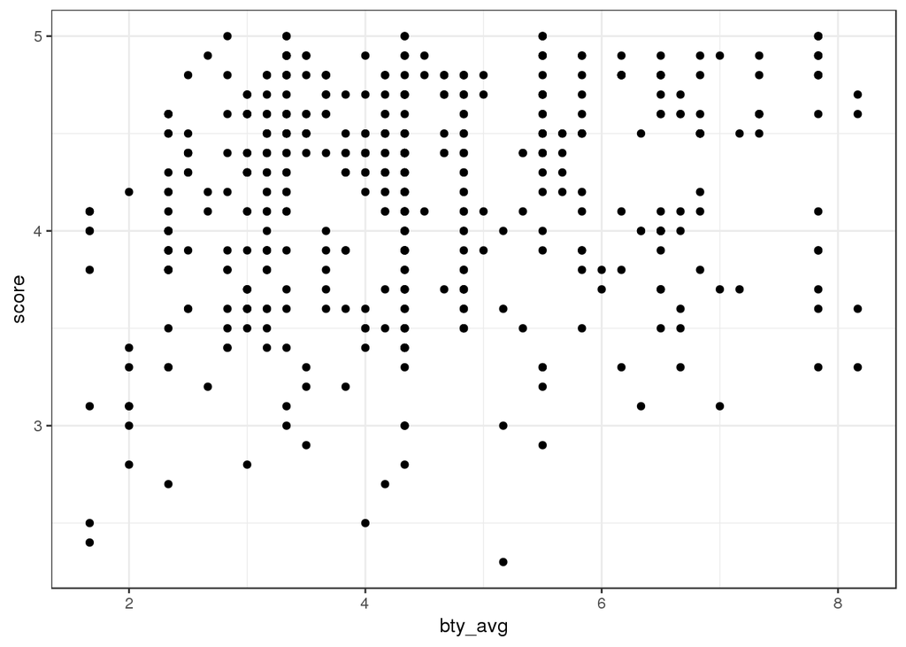

```r
library(ggplot2)
ggplot(data = evals, aes(x = bty_avg, y = score)) +
  geom_point() +
  theme_bw()
```

### 4.1.4 Create a scatterplot, with an added layer

Suppose you are interested in evaluating how the relationship between a professor’s attractiveness and their evaluation score varies across different class types (small, midsize, and large).

- Recreate your visualization from the previous exercise, but this time coloring the points by class type.
- How would you describe the relationship apparent in this visualization?

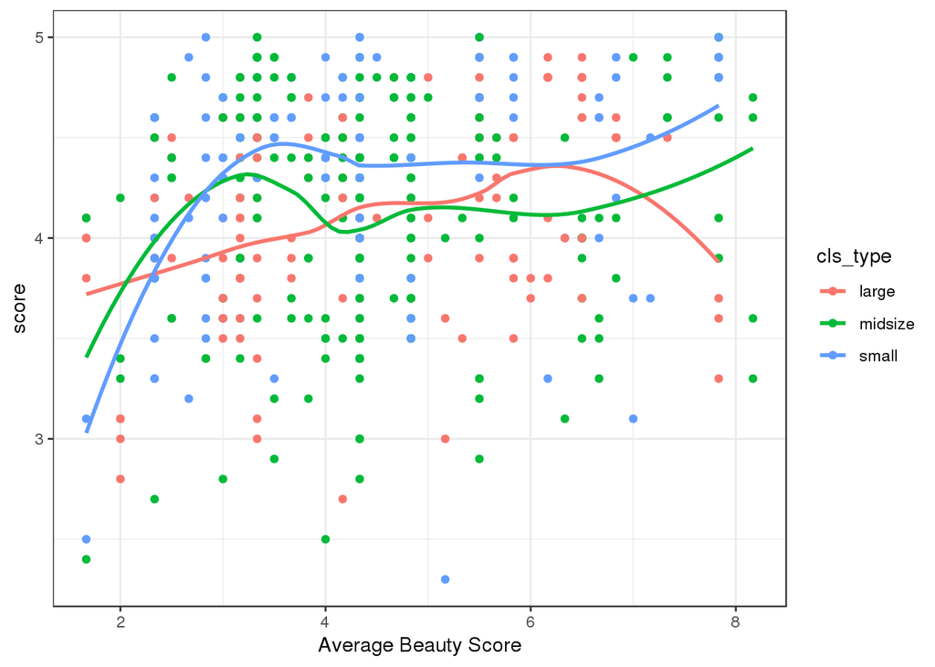

```r
library(ggplot2)
ggplot(data = evals, aes(x = bty_avg, y = score, color = cls_type)) +
  geom_point() +
  theme_bw() +
  labs(x = "Average Beauty Score") +
  geom_smooth(se = FALSE)
```